[figure not shown]

# `colorfindr`

This R package allows you to **extract colors** from various image types (currently JPEG, PNG, TIFF, SVG, BMP). Either a tailored **report** (directly with the main function `get_colors`), a **treemap** (`plot_colors`) or a **3D scatterplot** (`plot_colors_3d`) with the image color composition can be returned. Version 0.1.4 provides several methods for creating discrete **color palettes**.

## Installation

Version 0.1.3 is on CRAN and can be installed as follows:

```r
install.packages("colorfindr")
```

Install from GitHub for a regularly updated version (latest: 0.1.4):

```r
install.packages("devtools")
devtools::install_github("zumbov2/colorfindr")
```

# Treemap examples

## Color composition of the South African flag

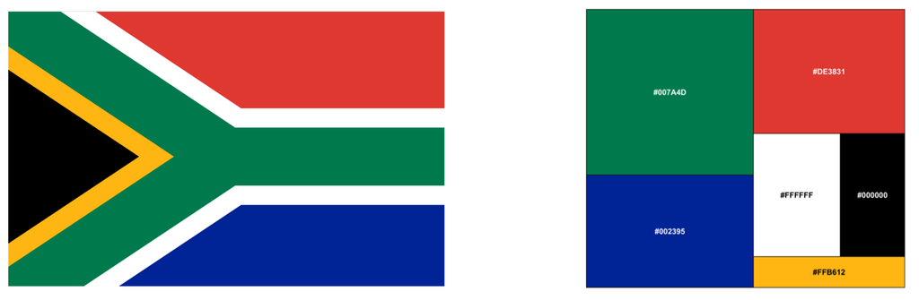

### Code

```r
# Load packages
pacman::p_load(colorfindr, dplyr)

# Plot
get_colors(
  img = "https://upload.wikimedia.org/wikipedia/commons/a/af/Flag_of_South_Africa.svg",
  min_share = 0.05
) %>%
  plot_colors(sort = "size")
```

## Flags of Swiss Cantons

[figure not shown]

### Code

```r
# Load packages
pacman::p_load(colorfindr, dplyr)

# Images
img <- c(
  "https://upload.wikimedia.org/wikipedia/commons/b/b5/Wappen_Aargau_matt.svg",
  "https://upload.wikimedia.org/wikipedia/commons/0/0e/Wappen_Glarus_matt.svg",
  "https://upload.wikimedia.org/wikipedia/commons/4/47/Wappen_Bern_matt.svg",
  "https://upload.wikimedia.org/wikipedia/commons/d/d1/Wappen_Neuenburg_matt.svg"
)

# Plot
for (i in 1:length(img)) get_colors(img[i], top_n = 4) %>% plot_colors(sort = "size")
```

# 3D Scatterplot examples

This part of the package was inspired by the wonderful plots of alfieish. They caused a sensation on [Reddit](https://www.reddit.com/r/dataisbeautiful/comments/7584no/3d_rgb_scatterplots_of_colours_used_in_famous/) in autumn 2017. The plots are created with [Plotly](https://plot.ly) and are accordingly interactive.

## Color composition of Edvard Munch’s *The Scream*

[figure not shown]

The original can be found under: https://plot.ly/~zumbov/14.embed.

### Code

```r
# Load packages
pacman::p_load(colorfindr, dplyr)

# Plot (5000 randomly selected pixels)
get_colors("https://upload.wikimedia.org/wikipedia/commons/f/f4/The_Scream.jpg") %>%
  plot_colors_3d(sample_size = 5000, marker_size = 2.5, color_space = "RGB")
```

## Color composition of Salvador Dalí’s *The Persistence of Memory*

[figure not shown]

The original can be found under: https://plot.ly/~zumbov/20.embed.

### Code

```r
# Load packages
pacman::p_load(colorfindr, dplyr)

# Plot (5000 randomly selected pixels)
get_colors("http://wisetoast.com/wp-content/uploads/2015/10/The-Persistence-of-Memory-salvador-deli-painting.jpg") %>%
  plot_colors_3d(sample_size = 5000, marker_size = 2.5, color_space = "RGB")
```

Read more [here](https://plot.ly/r/getting-started/) on how to publish your graphs to Plotly.

## Other masterpieces

Da Vinci’s [Mona Lisa](https://en.wikipedia.org/wiki/Mona_Lisa) -> [Color composition](https://plot.ly/~zumbov/10.embed)  
Vermeer’s [Girl with a Pearl Earring](https://en.wikipedia.org/wiki/Girl_with_a_Pearl_Earring) -> [Color composition](https://plot.ly/~zumbov/12.embed)  
Klimt’s The Kiss -> [Color composition](https://plot.ly/~zumbov/16.embed)  
Van Gogh’s [The Starry Night](https://en.wikipedia.org/wiki/The_Starry_Night) -> [Color composition](https://plot.ly/~zumbov/18.embed)

## Different color spaces

From version 0.1.2 on it is possible to display the point clouds in different color spaces: Besides …

[RGB](https://en.wikipedia.org/wiki/RGB_color_space)

[figure not shown]

HSV (hue, saturation, value) and …

[figure not shown]

[HSL](https://en.wikipedia.org/wiki/HSL_and_HSV) (hue, saturation, lightness) …

[figure not shown]

are available.

### Code

```r
# Load packages
pacman::p_load(dplyr, colorfindr)

# Get colors
col <- get_colors("http://joco.name/wp-content/uploads/2014/03/rgb_256_1.png")

# Plot to alternative color spaces
plot_colors_3d(col, color_space = "RGB")
plot_colors_3d(col, color_space = "HSV")
plot_colors_3d(col, color_space = "HSL")
```

# Creating color palettes

Version 0.1.4 provides various methods for creating color palettes with a distinct number of colors. The default method performs a [k-means](https://en.wikipedia.org/wiki/K-means_clustering) clustering on the pixels in the RGB color space (`clust_method = "kmeans"`). Alternatively, the pixel clusters can be created with a version of the [median cut](https://en.wikipedia.org/wiki/Median_cut) algorithm (`clust_method = "median_cut"`). The user can also choose whether the most common RGB combination per cluster is extracted (default: `extract_method = "hex_freq"`) or whether new RGB combinations are created for each cluster, either based on the mean (`extract_method = "mean"`), median (`extract_method = "median"`) or mode (`extract_method = "mode"`) of the RGB dimensions. The default has the advantage that the extracted colors actually appear in the image used. For images with many color nuances, however, the other extraction methods seem to achieve more convincing results.

## Childhood memories I

[figure not shown]

[figure not shown]

### Code

```r
# Load packages
pacman::p_load(dplyr, colorfindr)

# Ensure reproducibility
set.seed(123)

# Get colors and create a palette with n = 5
get_colors("https://www.movieart.ch/bilder_xl/tintin-et-milou-poster-11438_0_xl.jpg") %>%
make_palette(n = 5)
```

## Childhood memories II

[figure not shown]

[figure not shown]

### Code

```r
# Load packages
pacman::p_load(dplyr, colorfindr)

# Ensure reproducibility
set.seed(123)

# Get colors and create a palette with n = 5
get_colors("http://www.coverbrowser.com/image/lucky-luke/5-1.jpg") %>%
    make_palette(n = 5)
```

## Vintage ads from Switzerland I

[figure not shown]

[figure not shown]

### Code

```r
# Load packages
pacman::p_load(dplyr, colorfindr)

# Ensure reproducibility
set.seed(123)

# Get colors and create a palette with n = 5
get_colors("http://www.gallery29.ie/images/posters/1171469398_DSC03889.jpg") %>%
    make_palette(n = 5)
```

## Vintage ads from Switzerland II

[figure not shown]

[figure not shown]

### Code

```r
# Load packages
pacman::p_load(dplyr, colorfindr)

# Ensure reproducibility
set.seed(123)

# Get colors and create a palette with n = 5
get_colors("https://www.artifiche.com/cms/upload/posters_extralarge/2850.jpg") %>%
    make_palette(n = 5)
```

**Happy Testing!**